# HustleBall — Do Hustle Statistics in the NBA Matter?

### By Yonatan Klausner, Yair Fax, and Jonathan Rawson

#### Published: December 4, 2018

1. **Introduction**  
   A. Previous Work
2. **Data Scraping**  
   A. Define Functions for Obtaining Data  
   B. Get Hustle Data on Players  
   C. Get Data for Regular Statistics on Players  
   D. Get Data for Positions of Players  
   E. Get Data for Team Wins  
   F. Get Data for Salaries of Players  
   G. Get Team Statistics
3. **Clean Data**  
   A. Clean Hustle and Position Data  
   B. Clean Team Wins Data  
   C. Clean Salary Data
4. **Calculate Hustle Score**
5. **Look for Potential Correlation between HustleScore and Other Statistics**  
   A. Age vs. HustleScore  
   B. Minutes Played vs. HustleScore  
   C. Positions vs. HustleScore  
   D. HustleScore per Position between Top and Bottom Teams  
   E. Player Salary vs. HustleScore
6. **Predictions**  
   A. Player Point Prediction based on Base Hustle Scores  
   B. Player Point Prediction based on Calculated HustleScore  
   C. Predict Player Points with Regular Statistics  
   D. Incorporating the HustleScore  
   E. Predicting Team Wins based on Hustle Score
7. **There's no "I" in Team**  
   A. Plotting Team HustleScore vs. Wins  
   B. Top Teams vs. Bottom Teams
8. **Conclusion**

## 1. Introduction

As an [article](http://grantland.com/features/the-economics-moneyball/) in Grantland, a sports blog, puts it: "The Moneyball thesis is simple: Using statistical analysis, small-market teams can compete by buying assets that are undervalued by other teams and selling ones that are overvalued by other teams." The key to Moneyball is figuring out how to know when a player is "undervalued."

For our project, we will be looking at statistics in the National Basketball Association ([NBA](http://www.nba.com)). Among other statistics, we will mainly be looking at statistics that involve some sort of hustling. Hustle statistics try to measure how much effort a player puts in (i.e. how hard they play). These statistics include screen assists, deflections, loose balls recovered, charges drawn, contested shots, steals, and offensive rebounds, which we will explain in detail below. We would like to find some sort of correlation between a hustle score that we calculate ourselves and other statistics. Ideally, our findings will help teams seek specific players due to their hustle scores. To read more about hustle statistics, see this [article](https://stats.nba.com/articles/dig-deeper-into-the-game-with-new-defensive-and-hustle-data/).

### 1.A Previous Work

While there has been research relating to general statistics, little work as been done related to hustle statistics. Igor Stančin and Alan Jović of the University of Zagreb published a [paper](https://bib.irb.hr/datoteka/939840.MIPRO_2018_Stancin_Jovic_final_revised.pdf) looking into the differences winning teams and losing teams for several hustle statistics. However they do not calculate a total score for a player or for a team. Mark White and Kennon Sheldon published a [paper](https://link-springer-com.proxy-um.researchport.umd.edu/article/10.1007/s11031-013-9389-7) looking at players' performace before, during, and after their contract years. While they did look at several normal NBA statistics, such as field goal percentage, points, and rebounds, they did not incorporate advanced hustle statistics into their paper. Landon Drew Laporte wrote a [paper](https://repository.lib.ncsu.edu/bitstream/handle/1840.20/33510/etd.pdf?sequence=1) researching hustling in basketball. While his paper does go in depth on how to identify hustlers and how to predict hustling, he does not look for correlation with other statistics.

Additionally, the hustle statistics from the NBA have only existed since the beginning of the 2016-2017 season. Therefore, not a lot of work has been done concerning them. In our project we try to find significance in the NBA's advanced statistics.

```python
# Imports needed for project
from bs4 import BeautifulSoup
from selenium import webdriver
from selenium.webdriver.common.by import By
import requests
import pandas as pd
import numpy as np
import pylab as pl
%matplotlib inline
from IPython.core.pylabtools import figsize
import matplotlib.pyplot as plt
from sklearn.linear_model import LinearRegression
import seaborn as sns
```

```python
figsize(14, 7)
```

## 2. Data Scraping

In this section we get all the data that we will be using for our project.

### 2.A Define Functions for Obtaining Data

These functions get statistics from [NBA.com](http://nba.com). We use an automated browser ([link](https://webkit.org/blog/6900/webdriver-support-in-safari-10/) to read more) instead of a simple get request because the HTML is not fully populated in the request. The scripts on the page populate the table's data. We use javascript in the browser to edit elements of the page so that we can simulate clicks to display the full table. We then pull the HTML from the page and pass it to Pandas to create a dataframe.

```python
def getHustleStats(year):
    return getYearStats("https://stats.nba.com/players/hustle/?sort=MIN&dir=-1&Season=" + year + "&SeasonType=Regular%20Season", year)

def getRegularStats(year):
    return getYearStats("https://stats.nba.com/leaders/?Season=" + year + "&SeasonType=Regular%20Season", year)

def getYearStats(url, year):
    # Use an automated browser so that the webpage is rendered properly
    browser = webdriver.Safari()
    browser.get(url)

    # Edit HTML so that we can get the whole table
    browser.execute_script('document.getElementsByClassName("stats-table-pagination__select")[0].setAttribute("id", "btn")')
    browser.execute_script('document.getElementById("btn").children[0].setAttribute("id", "select-all")')
    nextButton = browser.find_element_by_id('btn')
    allButton = browser.find_element_by_id('select-all')

    # Click on buttons to get whole table
    nextButton.click()
    allButton.click()

    # Get HTML and parse
    innerHTML = browser.execute_script("return document.body.innerHTML")
    root = BeautifulSoup(innerHTML, "lxml")
    table = pd.read_html(str(root.find("table")))
    table = table[0]

    # Add year column for later table merging
    table['year'] = year
    browser.close()
    return table
```

This function uses a simple get request for a specific year to get data about players' positions.

```python
def getPositions(year):
    url = "https://www.basketball-reference.com/leagues/NBA_" + str(year) + "_per_game.html"
    r = requests.get(url)
    root = BeautifulSoup(r.content, "lxml")
    data = root.find("table")
    positions_table = pd.read_html(str(data))[0]
    positions_table['year'] = str(year - 1) + "-" + str(year - 2000)
    return positions_table
```

These functions read csv files stored on the git repository.

```python
def getTeams(filename, year):
    teamTable = pd.read_csv(filename)
    teamTable['year'] = year
    return teamTable

def getSalaries(filename):
    salaryTable = pd.read_csv(filename)
    return salaryTable
```

### 2.B Get Hustle Data on Players

This data consists of several statistics that are related to player hustling (see where we got the data from [here](https://stats.nba.com/players/hustle/?sort=MIN&dir=1&Season=2016-17&SeasonType=Regular%20Season)). Due to that these advanced statistics are only available for the past couple of years, we will only be using 2 full seasons of data (2016-2017 and 2017-2018).

```python
# Use our getHustleStats function to get the hustle stats for each year
hustle16_17 = getHustleStats("2016-17")
hustle17_18 = getHustleStats("2017-18")
```

```python
# Concatenate hustle tables together
hustleStats = hustle16_17.append(hustle17_18)
hustleStats.head()
```

|  | Player | TEAM | AGE | GP | MIN | ScreenAssists | ScreenAssists PTS | Deflections | OFF Loose BallsRecovered | DEF Loose BallsRecovered | Loose BallsRecovered | % Loose BallsRecovered OFF | % Loose BallsRecovered DEF | ChargesDrawn | Contested2PT Shots | Contested3PT Shots | ContestedShots | year |
| --- | --- | --- | --- | --- | --- | --- | --- | --- | --- | --- | --- | --- | --- | --- | --- | --- | --- | --- |
| 0 | Danuel House Jr. | WAS | 24 | 1 | 0.8 | 0.0 | 0.0 | 0.0 | 0.0 | 0.0 | 0.0 | 0.0 | 0.0 | 0.0 | 0.0 | 0.0 | 0.0 | 2016-17 |
| 1 | John Lucas III | MIN | 34 | 5 | 2.1 | 0.0 | 0.0 | 0.8 | 0.0 | 0.0 | 0.2 | 0.0 | 0.0 | 0.0 | 0.0 | 0.0 | 0.0 | 2016-17 |
| 2 | Larry Sanders | CLE | 28 | 5 | 2.5 | 0.2 | 0.4 | 0.2 | 0.0 | 0.0 | 0.2 | 0.0 | 0.0 | 0.0 | 1.4 | 0.0 | 1.4 | 2016-17 |
| 3 | Steve Novak | MIL | 34 | 8 | 2.7 | 0.0 | 0.0 | 0.0 | 0.0 | 0.0 | 0.0 | 0.0 | 0.0 | 0.0 | 0.4 | 0.1 | 0.5 | 2016-17 |
| 4 | Brice Johnson | LAC | 23 | 3 | 3.1 | 0.3 | 1.0 | 0.7 | 0.0 | 0.0 | 0.0 | 0.0 | 0.0 | 0.0 | 1.3 | 0.3 | 1.7 | 2016-17 |

### 2.C Get Data for Regular Statistics on Players

This data consists of several common player statistics such as **MIN** (minutes per game), **PTS** (points per game), **FGM** (field goals made per game), **REB** (rebounds per game), etc. (see where we got the data from [here](https://stats.nba.com/leaders/?Season=2016-17&SeasonType=Regular%20Season))

```python
# Get regular stats using our getRegularStats function and concatenate tables
regular16_17 = getRegularStats("2016-17")
regular17_18 = getRegularStats("2017-18")
regularStats = regular16_17.append(regular17_18)
regularStats.head()
```

|  | # | Player | GP | MIN | PTS | FGM | FGA | FG% | 3PM | 3PA | ... | FT% | OREB | DREB | REB | AST | STL | BLK | TOV | EFF | year |
| --- | --- | --- | --- | --- | --- | --- | --- | --- | --- | --- | --- | --- | --- | --- | --- | --- | --- | --- | --- | --- | --- |
| 0 | 1 | Russell Westbrook | 81 | 34.6 | 31.6 | 10.2 | 24.0 | 42.5 | 2.5 | 7.2 | ... | 84.5 | 1.7 | 9.0 | 10.7 | 10.4 | 1.6 | 0.4 | 5.4 | 33.8 | 2016-17 |
| 1 | 2 | James Harden | 81 | 36.4 | 29.1 | 8.3 | 18.9 | 44.0 | 3.2 | 9.3 | ... | 84.7 | 1.2 | 7.0 | 8.1 | 11.2 | 1.5 | 0.5 | 5.7 | 32.4 | 2016-17 |
| 2 | 3 | Isaiah Thomas | 76 | 33.8 | 28.9 | 9.0 | 19.4 | 46.3 | 3.2 | 8.5 | ... | 90.9 | 0.6 | 2.1 | 2.7 | 5.9 | 0.9 | 0.2 | 2.8 | 24.7 | 2016-17 |
| 3 | 4 | Anthony Davis | 75 | 36.1 | 28.0 | 10.3 | 20.3 | 50.5 | 0.5 | 1.8 | ... | 80.2 | 2.3 | 9.5 | 11.8 | 2.1 | 1.3 | 2.2 | 2.4 | 31.1 | 2016-17 |
| 4 | 5 | DeMar DeRozan | 74 | 35.4 | 27.3 | 9.7 | 20.9 | 46.7 | 0.4 | 1.7 | ... | 84.2 | 0.9 | 4.3 | 5.2 | 3.9 | 1.1 | 0.2 | 2.4 | 22.7 | 2016-17 |

5 rows × 23 columns

### 2.D Get Data for Positions of Players

This data consists of the positions for each player. The five positions are:

1. **PG** - point guard
2. **SG** - shooting guard
3. **SF** - small forward
4. **PF** - power forward
5. **C** - center

Typically, the **point guard** is the leader of the team when on the court. Being the point guard requires polished ball handling skills and the ability to facilitate the team during a play. The **shooting guard** is generally the best shooter and is usually capable of shooting from farther distances. Generally, they also have good ball-handling skills. The **small forward** often has an aggressive approach to the basket on offense. The **power forward** and the center are usually called "low post" players. They often act as their team's primary rebounders and shot blockers, and also generally get the ball closer to the hoop to take inside shots. The **center** is typically the larger of the two. To read more about the different positions in basketball, please click this [link](https://en.wikipedia.org/wiki/Basketball_positions).

```python
# Get position data from our getPositions function. We only need the player, position, and year from the table
positions16_17 = getPositions(2017)[['Player', 'Pos', 'year']]
positions17_18 = getPositions(2018)[['Player', 'Pos', 'year']]
```

```python
# Concatenate tables together
positionsTable = positions16_17.append(positions17_18)
positionsTable.head()
```

|  | Player | Pos | year |
| --- | --- | --- | --- |
| 0 | Alex Abrines | SG | 2016-17 |
| 1 | Quincy Acy | PF | 2016-17 |
| 2 | Quincy Acy | PF | 2016-17 |
| 3 | Quincy Acy | PF | 2016-17 |
| 4 | Steven Adams | C | 2016-17 |

### 2.E Get Data for Team Wins

This data consists of team statistics related to wins and losses. We use this data to get the number of wins for a team in a given year.

```python
# Use our getTeams function to read from CSV files and concatenate together
teamsWins16_17 = getTeams('teams_2016_2017.csv', '2016-17')
teamsWins17_18 = getTeams('teams_2017_2018.csv', '2017-18')
teamWinsTable = teamsWins16_17.append(teamsWins17_18)
teamWinsTable.head()
```

|  | Team | W | L | Win% | GB | Conf | Div | Home | Road | OT | Last 10 | Streak | year |
| --- | --- | --- | --- | --- | --- | --- | --- | --- | --- | --- | --- | --- | --- |
| 0 | BOS | 53 | 29 | 0.646 | 0 | 36-16 | 11-5 | 30-11 | 23-18 | 2-1 | 7-3 | W 3 | 2016-17 |
| 1 | CLE | 51 | 31 | 0.622 | 2 | 35-17 | 8-8 | 31-10 | 20-21 | 3-4 | 4-6 | L 4 | 2016-17 |
| 2 | TOR | 51 | 31 | 0.622 | 2 | 34-18 | 14-2 | 28-13 | 23-18 | 3-1 | 8-2 | W 4 | 2016-17 |
| 3 | WAS | 49 | 33 | 0.598 | 4 | 32-20 | 8-8 | 30-11 | 19-22 | 4-3 | 5-5 | L 1 | 2016-17 |
| 4 | ATL | 43 | 39 | 0.524 | 10 | 30-22 | 6-10 | 23-18 | 20-21 | 5-0 | 6-4 | L 1 | 2016-17 |

### 2.F Get Data for Salaries of Players

This [data](https://data.world/datadavis/nba-salaries) consists of player salaries.

```python
# Use our getSalaries function to read CSV file
salaryTable = getSalaries('player_salaries.csv')
salaryTable.head()
```

|  | Player | salary | season_end | year | team | team_name |
| --- | --- | --- | --- | --- | --- | --- |
| 0 | Moses Malone | 2406000 | 1991 | 1990 | ATL | Atlanta Hawks |
| 1 | Dominique Wilkins | 2065000 | 1991 | 1990 | ATL | Atlanta Hawks |
| 2 | Jon Koncak | 1550000 | 1991 | 1990 | ATL | Atlanta Hawks |
| 3 | Doc Rivers | 895000 | 1991 | 1990 | ATL | Atlanta Hawks |
| 4 | Rumeal Robinson | 800000 | 1991 | 1990 | ATL | Atlanta Hawks |

### 2.G Get Team Statistics

This data consists of aggregate player statistics for each team.

```python
# Use our getTeams function to read CSV files and concatenate tables
teamStats_16_17 = getTeams("team_stats_2016_2017.csv", '2016-17')
teamStats_17_18 = getTeams("team_stats_2017_2018.csv", '2017-18')
teamStatsTable = teamStats_16_17.append(teamStats_17_18)
teamStatsTable.head()
```

|  | Rk | Team | G | MP | FG | FGA | FG% | 3P | 3PA | 3P% | ... | ORB | DRB | TRB | AST | STL | BLK | TOV | PF | PTS | year |
| --- | --- | --- | --- | --- | --- | --- | --- | --- | --- | --- | --- | --- | --- | --- | --- | --- | --- | --- | --- | --- | --- |
| 0 | 1.0 | GSW | 82 | 241.2 | 43.1 | 87.1 | 0.495 | 12.0 | 31.2 | 0.383 | ... | 9.4 | 35.0 | 44.4 | 30.4 | 9.6 | 6.8 | 14.8 | 19.3 | 115.9 | 2016-17 |
| 1 | 2.0 | HOU | 82 | 241.2 | 40.3 | 87.2 | 0.462 | 14.4 | 40.3 | 0.357 | ... | 10.9 | 33.5 | 44.4 | 25.2 | 8.2 | 4.3 | 15.1 | 19.9 | 115.3 | 2016-17 |
| 2 | 3.0 | DEN | 82 | 240.9 | 41.2 | 87.7 | 0.469 | 10.6 | 28.8 | 0.368 | ... | 11.8 | 34.6 | 46.4 | 25.3 | 6.9 | 3.9 | 15.0 | 19.1 | 111.7 | 2016-17 |
| 3 | 4.0 | CLE | 82 | 242.4 | 39.9 | 84.9 | 0.470 | 13.0 | 33.9 | 0.384 | ... | 9.3 | 34.4 | 43.7 | 22.7 | 6.6 | 4.0 | 13.7 | 18.1 | 110.3 | 2016-17 |
| 4 | 5.0 | WAS | 82 | 242.1 | 41.3 | 87.0 | 0.475 | 9.2 | 24.8 | 0.372 | ... | 10.3 | 32.6 | 42.9 | 23.9 | 8.5 | 4.1 | 14.2 | 21.3 | 109.2 | 2016-17 |

5 rows × 26 columns

## 3. Clean Data

### 3.A Clean Hustle and Position Data

After getting all the data needed for our project, we need to clean the data so that we are able to use each table easily (short, informative [read](https://medium.com/datadriveninvestor/data-cleaning-for-data-scientist-363fbbf87e5f)).  
First, we merge the hustleStats table and the positionsTable on the player and year columns in order to add the positions to the hustleStats table.  
We then print out any players in the merged table with a null position to see which players were not assigned a position properly, meaning had inconsistent data between the two tables.

```python
hustleStatsTemp = pd.merge(hustleStats, positionsTable, on=['Player', 'year'], how='left')
# Print out all players with null position
hustleStatsTemp[pd.isnull(hustleStatsTemp['Pos'])]
```

|  | Player | TEAM | AGE | GP | MIN | ScreenAssists | ScreenAssists PTS | Deflections | OFF Loose BallsRecovered | DEF Loose BallsRecovered | Loose BallsRecovered | % Loose BallsRecovered OFF | % Loose BallsRecovered DEF | ChargesDrawn | Contested2PT Shots | Contested3PT Shots | ContestedShots | year | Pos |
| --- | --- | --- | --- | --- | --- | --- | --- | --- | --- | --- | --- | --- | --- | --- | --- | --- | --- | --- | --- |
| 0 | Danuel House Jr. | WAS | 24 | 1 | 0.8 | 0.0 | 0.0 | 0.0 | 0.0 | 0.0 | 0.0 | 0.0 | 0.0 | 0.00 | 0.0 | 0.0 | 0.0 | 2016-17 | NaN |
| 6 | RJ Hunter | CHI | 23 | 3 | 3.1 | 0.0 | 0.0 | 0.0 | 0.0 | 0.0 | 0.0 | 0.0 | 0.0 | 0.00 | 0.3 | 0.3 | 0.7 | 2016-17 | NaN |
| 21 | CJ Wilcox | ORL | 26 | 22 | 4.9 | 0.0 | 0.0 | 0.2 | 0.0 | 0.0 | 0.1 | 0.0 | 0.0 | 0.05 | 0.5 | 0.6 | 1.1 | 2016-17 | NaN |
| 40 | Johnny O'Bryant III | CHA | 24 | 11 | 7.3 | 0.6 | 1.4 | 0.2 | 0.0 | 0.0 | 0.3 | 0.0 | 0.0 | 0.00 | 1.1 | 0.4 | 1.4 | 2016-17 | NaN |
| 41 | AJ Hammons | DAL | 24 | 22 | 7.4 | 1.0 | 2.3 | 0.2 | 0.0 | 0.0 | 0.1 | 0.0 | 0.0 | 0.00 | 2.0 | 0.4 | 2.4 | 2016-17 | NaN |
| 92 | KJ McDaniels | BKN | 24 | 49 | 10.3 | 0.0 | 0.1 | 0.5 | 0.0 | 0.0 | 0.3 | 0.0 | 0.0 | 0.00 | 1.4 | 1.0 | 2.5 | 2016-17 | NaN |
| 128 | Wade Baldwin IV | MEM | 21 | 33 | 12.3 | 0.1 | 0.1 | 0.8 | 0.0 | 0.0 | 0.5 | 0.0 | 0.0 | 0.00 | 1.7 | 1.4 | 3.1 | 2016-17 | NaN |
| 154 | Juancho Hernangomez | DEN | 21 | 62 | 13.6 | 0.3 | 0.7 | 0.7 | 0.0 | 0.0 | 0.5 | 0.0 | 0.0 | 0.00 | 3.1 | 1.7 | 4.7 | 2016-17 | NaN |
| 236 | Gary Payton II | MIL | 24 | 6 | 16.5 | 0.3 | 0.7 | 1.3 | 0.0 | 0.0 | 0.3 | 0.0 | 0.0 | 0.00 | 2.2 | 1.3 | 3.5 | 2016-17 | NaN |
| 240 | Taurean Prince | ATL | 23 | 59 | 16.6 | 0.1 | 0.2 | 1.4 | 0.0 | 0.0 | 0.6 | 0.0 | 0.0 | 0.05 | 2.9 | 2.4 | 5.2 | 2016-17 | NaN |
| 246 | Derrick Jones Jr. | PHX | 20 | 32 | 17.0 | 0.2 | 0.3 | 0.8 | 0.0 | 0.0 | 0.3 | 0.0 | 0.0 | 0.03 | 2.5 | 1.6 | 4.1 | 2016-17 | NaN |
| 271 | Nene | HOU | 34 | 67 | 17.9 | 2.8 | 6.5 | 1.5 | 0.0 | 0.0 | 0.7 | 0.0 | 0.0 | 0.15 | 4.9 | 1.7 | 6.6 | 2016-17 | NaN |
| 324 | Kelly Oubre Jr. | WAS | 21 | 79 | 20.3 | 0.2 | 0.5 | 2.5 | 0.0 | 0.0 | 0.8 | 0.0 | 0.0 | 0.08 | 2.4 | 2.2 | 4.6 | 2016-17 | NaN |
| 333 | Glenn Robinson III | IND | 23 | 69 | 20.7 | 0.1 | 0.2 | 1.0 | 0.0 | 0.0 | 0.5 | 0.0 | 0.0 | 0.01 | 2.9 | 2.4 | 5.3 | 2016-17 | NaN |
| 372 | Larry Nance Jr. | LAL | 24 | 63 | 22.9 | 2.0 | 4.9 | 2.7 | 0.0 | 0.0 | 0.9 | 0.0 | 0.0 | 0.00 | 4.8 | 2.1 | 6.9 | 2016-17 | NaN |
| 378 | CJ Miles | IND | 30 | 76 | 23.4 | 0.2 | 0.5 | 1.2 | 0.0 | 0.0 | 0.6 | 0.0 | 0.0 | 0.12 | 2.5 | 2.6 | 5.1 | 2016-17 | NaN |
| 379 | James Ennis III | MEM | 26 | 64 | 23.4 | 0.4 | 0.9 | 1.5 | 0.0 | 0.0 | 0.8 | 0.0 | 0.0 | 0.03 | 3.1 | 2.4 | 5.5 | 2016-17 | NaN |
| 467 | Tim Hardaway Jr. | ATL | 25 | 79 | 27.3 | 0.4 | 1.0 | 1.3 | 0.0 | 0.0 | 0.6 | 0.0 | 0.0 | 0.11 | 2.9 | 3.5 | 6.4 | 2016-17 | NaN |
| 470 | PJ Tucker | TOR | 32 | 81 | 27.6 | 0.8 | 1.9 | 2.7 | 0.0 | 0.0 | 1.1 | 0.0 | 0.0 | 0.10 | 3.3 | 2.5 | 5.8 | 2016-17 | NaN |
| 476 | JJ Redick | LAC | 33 | 78 | 28.2 | 0.4 | 0.8 | 1.4 | 0.0 | 0.0 | 0.6 | 0.0 | 0.0 | 0.08 | 2.7 | 1.6 | 4.3 | 2016-17 | NaN |
| 485 | JR Smith | CLE | 31 | 41 | 29.0 | 0.6 | 1.3 | 2.1 | 0.0 | 0.0 | 0.8 | 0.0 | 0.0 | 0.05 | 2.5 | 2.8 | 5.3 | 2016-17 | NaN |
| 537 | Otto Porter Jr. | WAS | 24 | 80 | 32.6 | 0.6 | 1.5 | 2.9 | 0.0 | 0.0 | 1.2 | 0.0 | 0.0 | 0.05 | 4.4 | 3.3 | 7.6 | 2016-17 | NaN |
| 595 | Vincent Hunter | MEM | 23 | 4 | 1.9 | 0.0 | 0.0 | 0.0 | 0.0 | 0.0 | 0.0 | 0.0 | 0.0 | 0.00 | 0.5 | 0.5 | 1.0 | 2017-18 | NaN |
| 616 | Matt Williams Jr. | MIA | 24 | 3 | 3.8 | 0.0 | 0.0 | 0.7 | 0.0 | 0.0 | 0.0 | 0.0 | 0.0 | 0.00 | 0.3 | 0.0 | 0.3 | 2017-18 | NaN |
| 660 | Larry Drew II | NOP | 28 | 10 | 7.0 | 0.0 | 0.0 | 0.0 | 0.2 | 0.0 | 0.2 | 100.0 | 0.0 | 0.00 | 0.8 | 0.7 | 1.5 | 2017-18 | NaN |
| 661 | Walter Lemon Jr. | NOP | 25 | 5 | 7.0 | 0.0 | 0.0 | 0.0 | 0.0 | 0.0 | 0.0 | 0.0 | 0.0 | 0.00 | 1.4 | 0.2 | 1.6 | 2017-18 | NaN |
| 696 | TJ Leaf | IND | 21 | 53 | 8.7 | 0.3 | 0.6 | 0.2 | 0.1 | 0.1 | 0.2 | 54.5 | 45.5 | 0.00 | 1.8 | 1.1 | 2.8 | 2017-18 | NaN |
| 704 | RJ Hunter | HOU | 24 | 5 | 9.0 | 0.0 | 0.0 | 1.2 | 0.2 | 0.4 | 0.6 | 33.3 | 66.7 | 0.00 | 0.2 | 0.8 | 1.0 | 2017-18 | NaN |
| 707 | Derrick Walton Jr. | MIA | 23 | 16 | 9.2 | 0.0 | 0.0 | 0.5 | 0.3 | 0.3 | 0.5 | 50.0 | 50.0 | 0.00 | 1.0 | 0.6 | 1.6 | 2017-18 | NaN |
| 711 | Gary Payton II | LAL | 25 | 23 | 9.6 | 0.2 | 0.3 | 0.9 | 0.1 | 0.2 | 0.3 | 28.6 | 71.4 | 0.00 | 1.3 | 0.9 | 2.2 | 2017-18 | NaN |
| 729 | Johnny O'Bryant III | CHA | 25 | 36 | 10.5 | 1.1 | 2.3 | 0.4 | 0.3 | 0.1 | 0.4 | 76.9 | 23.1 | 0.14 | 2.4 | 0.5 | 2.9 | 2017-18 | NaN |
| 735 | Juancho Hernangomez | DEN | 22 | 25 | 11.1 | 0.2 | 0.4 | 0.5 | 0.2 | 0.2 | 0.3 | 50.0 | 50.0 | 0.04 | 2.3 | 1.5 | 3.8 | 2017-18 | NaN |
| 743 | Wade Baldwin IV | POR | 22 | 7 | 11.5 | 0.6 | 1.3 | 0.7 | 0.0 | 0.3 | 0.3 | 0.0 | 100.0 | 0.00 | 1.4 | 0.7 | 2.1 | 2017-18 | NaN |
| 747 | James Webb III | BKN | 24 | 10 | 12.0 | 0.6 | 1.5 | 0.6 | 0.0 | 0.2 | 0.2 | 0.0 | 100.0 | 0.00 | 1.4 | 0.7 | 2.1 | 2017-18 | NaN |
| 751 | Derrick Jones Jr. | MIA | 21 | 20 | 12.3 | 0.1 | 0.3 | 0.4 | 0.2 | 0.2 | 0.4 | 50.0 | 50.0 | 0.05 | 2.6 | 1.1 | 3.7 | 2017-18 | NaN |
| 807 | Andrew White III | ATL | 25 | 15 | 13.9 | 0.0 | 0.0 | 0.3 | 0.2 | 0.5 | 0.7 | 30.0 | 70.0 | 0.00 | 0.9 | 1.6 | 2.5 | 2017-18 | NaN |
| 828 | Nene | HOU | 35 | 52 | 14.6 | 2.0 | 4.9 | 1.4 | 0.1 | 0.3 | 0.5 | 25.0 | 75.0 | 0.04 | 3.5 | 1.9 | 5.4 | 2017-18 | NaN |
| 834 | Glenn Robinson III | IND | 24 | 23 | 14.7 | 0.1 | 0.2 | 0.8 | 0.2 | 0.3 | 0.4 | 40.0 | 60.0 | 0.00 | 2.2 | 1.5 | 3.7 | 2017-18 | NaN |
| 870 | Wes Iwundu | ORL | 23 | 62 | 16.5 | 0.1 | 0.2 | 0.8 | 0.1 | 0.3 | 0.5 | 30.0 | 70.0 | 0.05 | 1.8 | 1.7 | 3.5 | 2017-18 | NaN |
| 901 | Danuel House Jr. | PHX | 25 | 23 | 17.5 | 0.1 | 0.3 | 0.5 | 0.2 | 0.3 | 0.4 | 40.0 | 60.0 | 0.00 | 3.3 | 2.5 | 5.8 | 2017-18 | NaN |
| 929 | CJ Miles | TOR | 31 | 70 | 19.1 | 0.2 | 0.5 | 1.1 | 0.2 | 0.3 | 0.5 | 40.5 | 59.5 | 0.09 | 1.6 | 1.7 | 3.3 | 2017-18 | NaN |
| 986 | Larry Nance Jr. | CLE | 25 | 66 | 21.5 | 2.0 | 4.6 | 2.4 | 0.5 | 0.5 | 1.0 | 47.7 | 52.3 | 0.03 | 5.2 | 1.9 | 7.1 | 2017-18 | NaN |
| 1002 | James Ennis III | DET | 27 | 72 | 22.3 | 0.2 | 0.4 | 1.3 | 0.3 | 0.5 | 0.7 | 36.5 | 63.5 | 0.01 | 2.5 | 2.5 | 5.0 | 2017-18 | NaN |
| 1110 | Kelly Oubre Jr. | WAS | 22 | 81 | 27.5 | 0.2 | 0.6 | 2.7 | 0.4 | 0.5 | 0.9 | 41.4 | 58.6 | 0.12 | 3.5 | 2.9 | 6.3 | 2017-18 | NaN |
| 1115 | PJ Tucker | HOU | 33 | 82 | 27.8 | 1.3 | 3.2 | 1.6 | 0.5 | 0.8 | 1.2 | 38.6 | 61.4 | 0.13 | 3.9 | 2.7 | 6.7 | 2017-18 | NaN |
| 1123 | JR Smith | CLE | 32 | 80 | 28.1 | 0.5 | 1.3 | 1.5 | 0.3 | 0.6 | 0.8 | 31.8 | 68.2 | 0.04 | 2.2 | 2.8 | 5.0 | 2017-18 | NaN |
| 1140 | Dennis Smith Jr. | DAL | 20 | 69 | 29.7 | 0.5 | 1.1 | 2.1 | 0.7 | 0.6 | 1.3 | 53.9 | 46.1 | 0.06 | 3.3 | 3.7 | 7.1 | 2017-18 | NaN |
| 1146 | Taurean Prince | ATL | 24 | 82 | 30.0 | 0.2 | 0.5 | 1.8 | 0.5 | 0.6 | 1.1 | 43.3 | 56.7 | 0.11 | 3.8 | 2.8 | 6.6 | 2017-18 | NaN |
| 1148 | JJ Redick | PHI | 34 | 70 | 30.2 | 0.8 | 1.6 | 0.8 | 0.4 | 0.3 | 0.7 | 54.2 | 45.8 | 0.09 | 2.7 | 2.2 | 4.9 | 2017-18 | NaN |
| 1174 | Otto Porter Jr. | WAS | 25 | 77 | 31.6 | 0.6 | 1.4 | 2.9 | 0.3 | 0.9 | 1.2 | 27.2 | 72.8 | 0.01 | 3.2 | 2.3 | 5.5 | 2017-18 | NaN |
| 1198 | Tim Hardaway Jr. | NYK | 26 | 57 | 33.1 | 0.2 | 0.5 | 1.5 | 0.4 | 0.8 | 1.2 | 33.8 | 66.2 | 0.21 | 3.0 | 3.6 | 6.6 | 2017-18 | NaN |

As seen above, there are a number of players whose position was not set properly.  
After looking closely into each case, we realized what was going wrong.

1. For a number of the players, in one table they had a roman numeral added to the end of their name (e.g. "II") whereas in the other table it didn't have the roman numeral. For example, John Lucas III and John Lucas.
2. Some players in one table had suffixes such as "Jr." whereas in the other table they did not. For example, Kelly Oubre Jr. and Kelly Oubre.
3. A number of players had non-alphabetical characters in their names in one table and not in the other table. For example, C.J. Watson and CJ Watson.
4. Taurean Prince - in one table he was named "Taurean Prince" and in the other table he was named "Taurean Waller-Prince".
5. Nene - in one table he was named "Nene" and in the other table he was named "Nene Hilario".

We also drop all duplicate rows.

```python
def stripChars(series):
    # Use numpy string functions to strip unwanted characters from player names and return stripped name series
    return series.str.replace('Jr\.', '').str.replace('.', '').str.replace(',', '').str.replace('III', '').str.replace('II', '').str.replace('IV', '').str.rstrip()
```

```python
positionsTable = positionsTable.drop_duplicates(subset=['Player', 'year'])
positionsTable['Player'] = stripChars(positionsTable['Player'])
positionsTable.loc[positionsTable['Player'] == 'Nene Hilario', 'Player'] = 'Nene'
positionsTable.loc[positionsTable['Player'] == 'Taurean Waller-Prince', 'Player'] = 'Taurean Prince'
positionsTable.head()
```

|  | Player | Pos | year |
| --- | --- | --- | --- |
| 0 | Alex Abrines | SG | 2016-17 |
| 1 | Quincy Acy | PF | 2016-17 |
| 4 | Steven Adams | C | 2016-17 |
| 5 | Arron Afflalo | SG | 2016-17 |
| 6 | Alexis Ajinca | C | 2016-17 |

After cleaning the data some more, we then merge the hustleStats table and the postionsTable again.  
We then print the rows in the hustleStats that have a null position to see which player names are still inconsistent.

```python
hustleStats['Player'] = stripChars(hustleStats['Player'])
hustleStats = pd.merge(hustleStats, positionsTable, on=['Player', 'year'], how='left')
hustleStats[pd.isnull(hustleStats['Pos'])]
```

|  | Player | TEAM | AGE | GP | MIN | ScreenAssists | ScreenAssists PTS | Deflections | OFF Loose BallsRecovered | DEF Loose BallsRecovered | Loose BallsRecovered | % Loose BallsRecovered OFF | % Loose BallsRecovered DEF | ChargesDrawn | Contested2PT Shots | Contested3PT Shots | ContestedShots | year | Pos |
| --- | --- | --- | --- | --- | --- | --- | --- | --- | --- | --- | --- | --- | --- | --- | --- | --- | --- | --- | --- |
| 134 | Juancho Hernangomez | DEN | 21 | 62 | 13.6 | 0.3 | 0.7 | 0.7 | 0.0 | 0.0 | 0.5 | 0.0 | 0.0 | 0.00 | 3.1 | 1.7 | 4.7 | 2016-17 | NaN |
| 492 | Vincent Hunter | MEM | 23 | 4 | 1.9 | 0.0 | 0.0 | 0.0 | 0.0 | 0.0 | 0.0 | 0.0 | 0.0 | 0.00 | 0.5 | 0.5 | 1.0 | 2017-18 | NaN |
| 552 | Walter Lemon | NOP | 25 | 5 | 7.0 | 0.0 | 0.0 | 0.0 | 0.0 | 0.0 | 0.0 | 0.0 | 0.0 | 0.00 | 1.4 | 0.2 | 1.6 | 2017-18 | NaN |
| 605 | Juancho Hernangomez | DEN | 22 | 25 | 11.1 | 0.2 | 0.4 | 0.5 | 0.2 | 0.2 | 0.3 | 50.0 | 50.0 | 0.04 | 2.3 | 1.5 | 3.8 | 2017-18 | NaN |
| 709 | Wes Iwundu | ORL | 23 | 62 | 16.5 | 0.1 | 0.2 | 0.8 | 0.1 | 0.3 | 0.5 | 30.0 | 70.0 | 0.05 | 1.8 | 1.7 | 3.5 | 2017-18 | NaN |

These 5 players are relatively insignificant, so we drop them.

```python
hustleStats = hustleStats.dropna(subset=['Pos'])
hustleStats.head()
```

|  | Player | TEAM | AGE | GP | MIN | ScreenAssists | ScreenAssists PTS | Deflections | OFF Loose BallsRecovered | DEF Loose BallsRecovered | Loose BallsRecovered | % Loose BallsRecovered OFF | % Loose BallsRecovered DEF | ChargesDrawn | Contested2PT Shots | Contested3PT Shots | ContestedShots | year | Pos |
| --- | --- | --- | --- | --- | --- | --- | --- | --- | --- | --- | --- | --- | --- | --- | --- | --- | --- | --- | --- |
| 0 | Danuel House | WAS | 24 | 1 | 0.8 | 0.0 | 0.0 | 0.0 | 0.0 | 0.0 | 0.0 | 0.0 | 0.0 | 0.0 | 0.0 | 0.0 | 0.0 | 2016-17 | SG |
| 1 | John Lucas | MIN | 34 | 5 | 2.1 | 0.0 | 0.0 | 0.8 | 0.0 | 0.0 | 0.2 | 0.0 | 0.0 | 0.0 | 0.0 | 0.0 | 0.0 | 2016-17 | PG |
| 2 | Larry Sanders | CLE | 28 | 5 | 2.5 | 0.2 | 0.4 | 0.2 | 0.0 | 0.0 | 0.2 | 0.0 | 0.0 | 0.0 | 1.4 | 0.0 | 1.4 | 2016-17 | C |
| 3 | Steve Novak | MIL | 34 | 8 | 2.7 | 0.0 | 0.0 | 0.0 | 0.0 | 0.0 | 0.0 | 0.0 | 0.0 | 0.0 | 0.4 | 0.1 | 0.5 | 2016-17 | PF |
| 4 | Brice Johnson | LAC | 23 | 3 | 3.1 | 0.3 | 1.0 | 0.7 | 0.0 | 0.0 | 0.0 | 0.0 | 0.0 | 0.0 | 1.3 | 0.3 | 1.7 | 2016-17 | PF |

```python
# Get all position values
hustleStats['Pos'].unique()
```

```
array(['SG', 'PG', 'C', 'PF', 'SF', 'PF-C', 'SF-SG', 'PG-SG'],
      dtype=object)
```

Next, we clean the hustleStats table.

1. Change the "TEAM" column to be named 'Team'
2. Change any player with two positions to one
3. Drop unused columns
4. Drop duplicate players within the same year

```python
hustleStats = hustleStats.rename(columns = {'TEAM': 'Team'}) # Rename column
# Change position of player from multiple positions to one
hustleStats.loc[hustleStats['Pos'] == 'PG-SG', 'Pos'] = 'PG'
hustleStats.loc[hustleStats['Pos'] == 'SF-SG', 'Pos'] = 'SF'
hustleStats.loc[hustleStats['Pos'] == 'PF-C', 'Pos'] = 'PF'
# Drop unused columns
hustleStats = hustleStats.drop(['ScreenAssists PTS', 'OFF Loose BallsRecovered', 'DEF Loose BallsRecovered', '% Loose BallsRecovered OFF', '% Loose BallsRecovered DEF'], axis=1)
hustleStats = hustleStats.drop_duplicates(subset=['Player', 'year'])
hustleStats.head()
```

|  | Player | Team | AGE | GP | MIN | ScreenAssists | Deflections | Loose BallsRecovered | ChargesDrawn | Contested2PT Shots | Contested3PT Shots | ContestedShots | year | Pos |
| --- | --- | --- | --- | --- | --- | --- | --- | --- | --- | --- | --- | --- | --- | --- |
| 0 | Danuel House | WAS | 24 | 1 | 0.8 | 0.0 | 0.0 | 0.0 | 0.0 | 0.0 | 0.0 | 0.0 | 2016-17 | SG |
| 1 | John Lucas | MIN | 34 | 5 | 2.1 | 0.0 | 0.8 | 0.2 | 0.0 | 0.0 | 0.0 | 0.0 | 2016-17 | PG |
| 2 | Larry Sanders | CLE | 28 | 5 | 2.5 | 0.2 | 0.2 | 0.2 | 0.0 | 1.4 | 0.0 | 1.4 | 2016-17 | C |
| 3 | Steve Novak | MIL | 34 | 8 | 2.7 | 0.0 | 0.0 | 0.0 | 0.0 | 0.4 | 0.1 | 0.5 | 2016-17 | PF |
| 4 | Brice Johnson | LAC | 23 | 3 | 3.1 | 0.3 | 0.7 | 0.0 | 0.0 | 1.3 | 0.3 | 1.7 | 2016-17 | PF |

```python
# Verify that no player has multiple positions
hustleStats['Pos'].unique()
```

```
array(['SG', 'PG', 'C', 'PF', 'SF'], dtype=object)
```

### 3.B Clean Team Wins Data

```python
# Drop unused columns
teamWinsTable = teamWinsTable.drop(['L', 'Win%', 'GB', 'Conf', 'Div', 'Home', 'Road', 'OT', 'Last 10', 'Streak'], axis=1)
teamWinsTable = teamWinsTable.rename(columns = {'W': 'Wins'}) # Rename column
teamWinsTable.head()
```

|  | Team | Wins | year |
| --- | --- | --- | --- |
| 0 | BOS | 53 | 2016-17 |
| 1 | CLE | 51 | 2016-17 |
| 2 | TOR | 51 | 2016-17 |
| 3 | WAS | 49 | 2016-17 |
| 4 | ATL | 43 | 2016-17 |

### 3.C Clean Salary Data

```python
salaryTable = salaryTable[salaryTable['year'] >= 2017]
salaryTable = salaryTable.drop(['team_name', 'season_end', 'team'], axis=1)
salaryTable = salaryTable.drop_duplicates(subset=['Player', 'year'])
salaryTable.loc[salaryTable['year'] == 2016, 'year'] = '2016-17'
salaryTable.loc[salaryTable['year'] == 2017, 'year'] = '2017-18'
salaryTable.head()
```

|  | Player | salary | year |
| --- | --- | --- | --- |
| 414 | Kent Bazemore | 16910113 | 2017-18 |
| 415 | Dennis Schroder | 15500000 | 2017-18 |
| 416 | Miles Plumlee | 12500000 | 2017-18 |
| 417 | Jamal Crawford | 10942762 | 2017-18 |
| 418 | Marco Belinelli | 6606060 | 2017-18 |

All our data is now clean.

## 4. Calculate Hustle Score

The statistics we will use to calculate our hustle score are:

1. **Screen Assists** — A screen is a blocking move by an offensive player, by standing beside or behind a defender, to free a teammate to shoot, receive a pass, or drive in to score. A screen assist is a screen that directly leads to a made field goal.
2. **Deflections** — A deflection occurs when a defensive player redirects the intended direction of the ball.
3. **Loose Balls Recovered** — A loose ball is when neither team is in control of the ball. A loose ball recovered is when a player recovers a loose ball.
4. **Charges Drawn** — A charge, or player-control foul, occurs when a dribbler charges into a defender who has already established his position. When a defender takes a charge on an offensive player, the defensive player is awarded a drawn charge.
5. **Contested Shots** — A contested shot is when a defender is within 4 ft of the person shooting.
6. **Steals** — A steal is when a defender legally causes a turnover by his positive aggressive actions.
7. **Offensive Rebound** — An offensive rebound is when an offensive player secures a rebound.

These stastics are all hustle related, meaning players who hustle generally have higher values for these statistics. Therefore, these are the 7 statistics we use to calculate our hustle score.

(Definitions taken from [Wikipedia](http://wikipedia.org))

In order to calculate our hustle score, we will use the sum of screen assists, deflections, loose balls recovered, charges drawn, contested shots, steals, and offensive rebounds. However, if we just took the sum of those statistics for each player, certain statistics, such as contested shots, would effect the overall hustle score more than others because their numbers are generally higher. Therefore, we decided to normalize each statistic by dividing its value by the max for that specific statistic. Finally, we calculate this hustle score on a per 36-minute basis, as is normal when calculating statistics in basketball. [Read more](https://bleacherreport.com/articles/657235-the-value-of-per-36-statistics-and-future-breakthrough-stars#slide0)

```python
# Merge offensive rebounds and steals into hustleStats table for HustleScore calculation
hustleStats = hustleStats.merge(regularStats[['Player', 'year', 'OREB', 'STL']], on=['Player', 'year'])
hustleStats.head()
```

|  | Player | Team | AGE | GP | MIN | ScreenAssists | Deflections | Loose BallsRecovered | ChargesDrawn | Contested2PT Shots | Contested3PT Shots | ContestedShots | year | Pos | OREB | STL |
| --- | --- | --- | --- | --- | --- | --- | --- | --- | --- | --- | --- | --- | --- | --- | --- | --- |
| 0 | Cole Aldrich | MIN | 28 | 62 | 8.6 | 1.2 | 1.0 | 0.3 | 0.00 | 3.0 | 0.6 | 3.6 | 2016-17 | C | 0.8 | 0.4 |
| 1 | JaVale McGee | GSW | 29 | 77 | 9.6 | 0.9 | 0.3 | 0.2 | 0.00 | 4.2 | 0.8 | 5.1 | 2016-17 | C | 1.3 | 0.2 |
| 2 | Wesley Johnson | LAC | 29 | 68 | 11.9 | 0.5 | 1.4 | 0.3 | 0.00 | 2.4 | 1.2 | 3.5 | 2016-17 | SF | 0.4 | 0.4 |
| 3 | Davis Bertans | SAS | 24 | 67 | 12.1 | 0.6 | 0.6 | 0.3 | 0.04 | 3.3 | 1.1 | 4.3 | 2016-17 | PF | 0.3 | 0.3 |
| 4 | Salah Mejri | DAL | 31 | 73 | 12.4 | 1.5 | 0.8 | 0.4 | 0.30 | 4.9 | 0.5 | 5.4 | 2016-17 | C | 1.3 | 0.4 |

```python
# Calculate maximums to normalize aggregate hustle statistic
maxScreenAssists = (hustleStats['ScreenAssists']).max()
maxDeflections = (hustleStats['Deflections']).max()
maxLooseBallsRecovered = (hustleStats['Loose BallsRecovered']).max()
maxChargesDrawn = (hustleStats['ChargesDrawn']).max()
maxContestedShots = (hustleStats['ContestedShots']).max()
maxOREB = (hustleStats['OREB']).max()
maxSTL = (hustleStats['STL']).max()
print("maxScreenAssists per game: \t\t" + str(maxScreenAssists))
print("maxDeflections per game: \t\t" + str(maxDeflections))
print("maxLooseBallsRecovered per game: \t" + str(maxLooseBallsRecovered))
print("maxChargesDrawn per game: \t\t" + str(maxChargesDrawn))
print("maxContestedShots per game: \t\t" + str(maxContestedShots))
print("maxOffensiveRebound per game: \t\t" + str(maxOREB))
print("maxSteals per game: \t\t\t" + str(maxSTL))
```

```
maxScreenAssists per game: 		6.2
maxDeflections per game: 		4.2
maxLooseBallsRecovered per game: 	2.1
maxChargesDrawn per game: 		0.47
maxContestedShots per game: 		16.1
maxOffensiveRebound per game: 		5.1
maxSteals per game: 			2.4
```

```python
# Calculate hustle score
hustleStats['HustleScore'] = 36*(hustleStats['ScreenAssists']/maxScreenAssists + hustleStats['Deflections']/maxDeflections + hustleStats['Loose BallsRecovered']/maxLooseBallsRecovered + hustleStats['ChargesDrawn']/maxChargesDrawn + hustleStats['ContestedShots']/maxContestedShots + hustleStats['OREB']/maxOREB + hustleStats['STL']/maxSTL)/(hustleStats['MIN'])
hustleStats.head()
```

|  | Player | Team | AGE | GP | MIN | ScreenAssists | Deflections | Loose BallsRecovered | ChargesDrawn | Contested2PT Shots | Contested3PT Shots | ContestedShots | year | Pos | OREB | STL | HustleScore |
| --- | --- | --- | --- | --- | --- | --- | --- | --- | --- | --- | --- | --- | --- | --- | --- | --- | --- |
| 0 | Cole Aldrich | MIN | 28 | 62 | 8.6 | 1.2 | 1.0 | 0.3 | 0.00 | 3.0 | 0.6 | 3.6 | 2016-17 | C | 0.8 | 0.4 | 4.695207 |
| 1 | JaVale McGee | GSW | 29 | 77 | 9.6 | 0.9 | 0.3 | 0.2 | 0.00 | 4.2 | 0.8 | 5.1 | 2016-17 | C | 1.3 | 0.2 | 3.625625 |
| 2 | Wesley Johnson | LAC | 29 | 68 | 11.9 | 0.5 | 1.4 | 0.3 | 0.00 | 2.4 | 1.2 | 3.5 | 2016-17 | SF | 0.4 | 0.4 | 3.083672 |
| 3 | Davis Bertans | SAS | 24 | 67 | 12.1 | 0.6 | 0.6 | 0.3 | 0.04 | 3.3 | 1.1 | 4.3 | 2016-17 | PF | 0.3 | 0.3 | 2.732725 |
| 4 | Salah Mejri | DAL | 31 | 73 | 12.4 | 1.5 | 0.8 | 0.4 | 0.30 | 4.9 | 0.5 | 5.4 | 2016-17 | C | 1.3 | 0.4 | 5.859169 |

## 5. Look for Potential Correlation between HustleScore and Other Statistics

### 5.A Age vs. HustleScore

We hypothesize that younger player might hustle more.

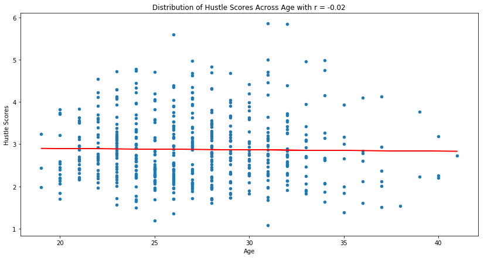

```python
scatter = hustleStats.plot.scatter('AGE', 'HustleScore')

(m, b) = np.polyfit(hustleStats['AGE'], hustleStats['HustleScore'], 1)
# Calculate the actual best fit line
regression_line = [(m*x)+b for x in hustleStats['AGE']]
scatter.plot(hustleStats['AGE'], regression_line, color='red')
# Calculate the correlation coefficient r
correlation = np.corrcoef(hustleStats['HustleScore'], hustleStats['AGE'])[0,1]

# Label the plot
scatter.set_title("Distribution of Hustle Scores Across Age with r = " + str(round(correlation,2)))
scatter.set_xlabel("Age")
scatter.set_ylabel("Hustle Scores")
```

The above plot shows basically no correlation between age and hustle scores.

### 5.B Minutes Played vs. HustleScore

We hypothesize that players who play less minutes hustle more.

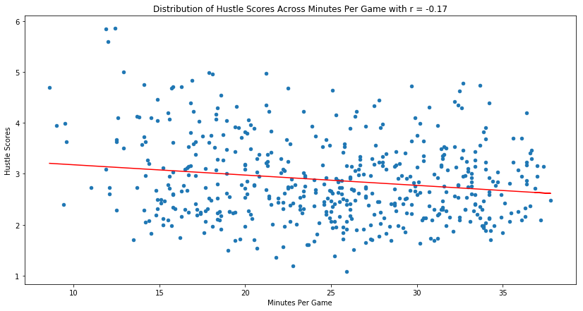

```python
scatter = hustleStats.plot.scatter('MIN', 'HustleScore')

(m, b) = np.polyfit(hustleStats['MIN'], hustleStats['HustleScore'], 1)
# Calculate the actual best fit line
regression_line = [(m*x)+b for x in hustleStats['MIN']]
scatter.plot(hustleStats['MIN'], regression_line, color='red')

# Calculate the correlation coefficient r
correlation = np.corrcoef(hustleStats['HustleScore'], hustleStats['MIN'])[0,1]

# Label the plot
scatter.set_title("Distribution of Hustle Scores Across Minutes Per Game with r = " + str(round(correlation,2)))
scatter.set_xlabel("Minutes Per Game")
scatter.set_ylabel("Hustle Scores")
```

The above plot shows a slight negative correlation between minutes per game and hustle scores. That is to say that as a player's minutes per game increases, a player's hustle score generally decreases slightly.

### 5.C Position vs. HustleScore

We hypothesize that some positions might have a higher hustle score than others.

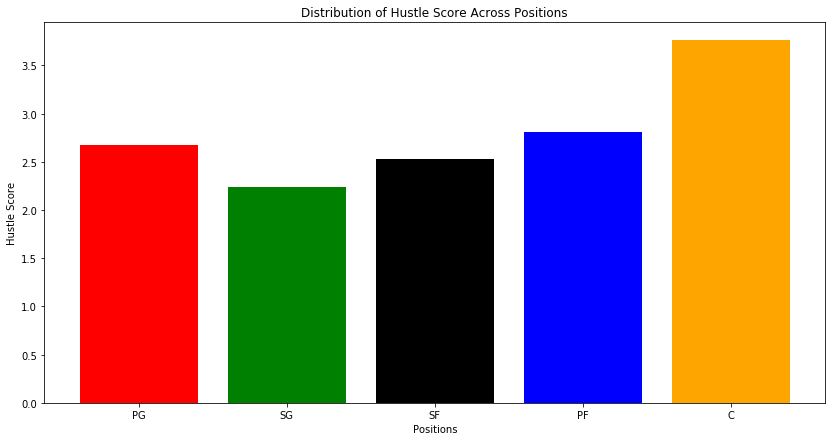

```python
positions = ['PG', 'SG', 'SF', 'PF', 'C']
hustlePerPos = []
for pos in positions:
    hustlePerPos.append(hustleStats[hustleStats['Pos'] == pos]['HustleScore'].median())

fig, ax = plt.subplots()
ax.bar(positions, hustlePerPos, color = ['red', 'green', 'black', 'blue', 'orange'])
ax.set_xlabel("Positions")
ax.set_ylabel("Hustle Score")
ax.set_title("Distribution of Hustle Score Across Positions")
```

As seen in the above plot, there is a correlation between hustle score and position. Centers generally are more likely to have a higher hustle score. This could be because centers hustle more, however, it could also be due to the way we calculate our hustle score.

### 5.D HustleScore per Position between Top and Bottom Teams

We think that there might be a difference in hustle score between bottom and top teams by position.  
We define a top team to have 48 or more wins because playoff teams generally have more than 48 wins.

```python
# Define a top team as having more than or equal to 48 wins
topTeams = teamWinsTable[teamWinsTable['Wins'] >= 48]
bottomTeams = teamWinsTable[teamWinsTable['Wins'] < 48]
```

```python
topTeamsPlayers = pd.merge(topTeams, hustleStats, how='left', on=['Team']).sort_values('Pos')
bottomTeamsPlayers = pd.merge(bottomTeams, hustleStats, how='left', on=['Team']).sort_values('Pos')
```

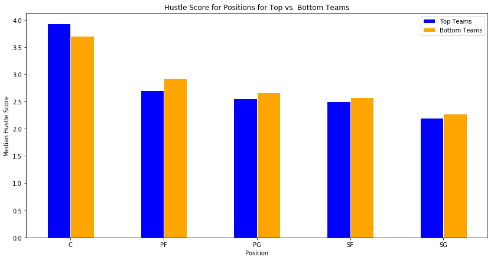

```python
# Set width of bars
barWidth = 0.25

# Set height of bars
bars1 = topTeamsPlayers.groupby(['Pos']).median()['HustleScore']
bars2 = bottomTeamsPlayers.groupby(['Pos']).median()['HustleScore']

# Set position of bars on x axis
r1 = np.arange(len(bars1))
r2 = [x + barWidth for x in r1]

# Make the plot
plt.bar(r1, bars1, color='blue', width=barWidth, edgecolor='white', label='Top Teams')
plt.bar(r2, bars2, color='orange', width=barWidth, edgecolor='white', label='Bottom Teams')

# Add xticks on the middle of the group bars
plt.xlabel('Position')
plt.ylabel('Median Hustle Score')
plt.xticks([r + barWidth/2 for r in range(len(bars1))], ['C', 'PF', 'PG', 'SF', 'SG'])
plt.title("Hustle Score for Positions for Top vs. Bottom Teams")

# Create legend and show plot
plt.legend()
plt.show()
```

As seen in the above plot, the top teams generally have a center that hustles more than centers on the bottom teams. In the other positions players on bottom teams tend to hustle more. However, the differences are not significant.

### 5.E Player Salary vs. HustleScore

We explore if teams pay more for players that hustle more.

```python
salaryHustle = pd.merge(hustleStats, salaryTable, on=['Player', 'year'], how='inner')
salaryHustle.head()
```

|  | Player | Team | AGE | GP | MIN | ScreenAssists | Deflections | Loose BallsRecovered | ChargesDrawn | Contested2PT Shots | Contested3PT Shots | ContestedShots | year | Pos | OREB | STL | HustleScore | salary |
| --- | --- | --- | --- | --- | --- | --- | --- | --- | --- | --- | --- | --- | --- | --- | --- | --- | --- | --- |
| 0 | Brandon Paul | SAS | 27 | 64 | 9.0 | 0.1 | 0.7 | 0.3 | 0.17 | 0.9 | 0.9 | 1.8 | 2017-18 | SG | 0.1 | 0.4 | 3.941723 | 815615 |
| 1 | Malik Beasley | DEN | 21 | 62 | 9.4 | 0.0 | 0.4 | 0.4 | 0.05 | 1.1 | 0.7 | 1.8 | 2017-18 | SG | 0.2 | 0.2 | 2.399161 | 1700640 |
| 2 | JaVale McGee | GSW | 30 | 65 | 9.5 | 1.1 | 0.7 | 0.2 | 0.00 | 4.0 | 1.1 | 5.0 | 2017-18 | C | 0.9 | 0.3 | 3.984077 | 2116955 |
| 3 | Cedi Osman | CLE | 23 | 61 | 11.0 | 0.1 | 0.8 | 0.4 | 0.02 | 1.6 | 1.1 | 2.7 | 2017-18 | SF | 0.3 | 0.4 | 2.725615 | 2642857 |
| 4 | Salah Mejri | DAL | 32 | 61 | 11.9 | 2.2 | 0.6 | 0.5 | 0.18 | 5.0 | 1.1 | 6.0 | 2017-18 | C | 1.4 | 0.4 | 5.846573 | 1471382 |

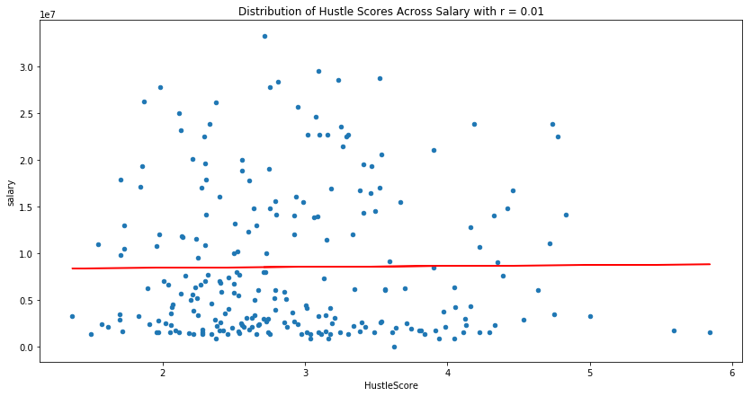

```python
scatter = salaryHustle.plot.scatter('HustleScore', 'salary')

(m, b) = np.polyfit(salaryHustle['HustleScore'], salaryHustle['salary'], 1)
# Calculate the actual best fit line
regression_line = [(m*x)+b for x in salaryHustle['HustleScore']]
scatter.plot(salaryHustle['HustleScore'], regression_line, color='red')
# Calculate the correlation coefficient r
correlation = np.corrcoef(salaryHustle['HustleScore'], salaryHustle['salary'])[0,1]

# Label the plot
scatter.set_title("Distribution of Hustle Scores Across Salary with r = " + str(round(correlation,2)))
```

As seen in the above plot, there is basically no correlation between a player's hustle score and his salary.

## 6. Predictions

In the following section, we try to use our calculated hustle score to predict other statistics, using Linear Regression models.

### 6.A Player Point Prediction based on Base Hustle Scores

We try to predict how many points a player gets based on his base hustle stats, where base hustle stats are the individual statistics from the NBA's website that we used to calculate our hustle score.

```python
# Get table with all the hustle stats and the points for each player
hustleStatsWithPTS = hustleStats.merge(regularStats[['Player', 'PTS', 'year']], on=['Player', 'year'], how='left')
hustleStatsWithPTS = hustleStatsWithPTS.dropna()
hustleStatsWithPTS = hustleStatsWithPTS.sort_values(by=['year', 'PTS'], ascending=False)
hustleStatsWithPTS.head()
```

|  | Player | Team | AGE | GP | MIN | ScreenAssists | Deflections | Loose BallsRecovered | ChargesDrawn | Contested2PT Shots | Contested3PT Shots | ContestedShots | year | Pos | OREB | STL | HustleScore | PTS |
| --- | --- | --- | --- | --- | --- | --- | --- | --- | --- | --- | --- | --- | --- | --- | --- | --- | --- | --- |
| 495 | James Harden | HOU | 28 | 72 | 35.4 | 0.3 | 2.9 | 1.3 | 0.03 | 4.4 | 3.1 | 7.6 | 2017-18 | SG | 0.6 | 1.8 | 2.808241 | 30.4 |
| 501 | Anthony Davis | NOP | 25 | 75 | 36.4 | 3.9 | 2.4 | 1.5 | 0.15 | 9.8 | 4.5 | 14.3 | 2017-18 | PF | 2.5 | 1.5 | 4.190727 | 28.1 |
| 508 | LeBron James | CLE | 33 | 82 | 36.9 | 1.0 | 2.2 | 1.1 | 0.15 | 4.0 | 3.0 | 7.0 | 2017-18 | PF | 1.2 | 1.4 | 2.713628 | 27.5 |
| 504 | Damian Lillard | POR | 27 | 73 | 36.6 | 0.2 | 1.8 | 1.7 | 0.11 | 2.8 | 1.9 | 4.7 | 2017-18 | PG | 0.8 | 1.1 | 2.371984 | 26.9 |
| 506 | Giannis Antetokounmpo | MIL | 23 | 75 | 36.7 | 1.4 | 2.5 | 1.8 | 0.00 | 6.6 | 3.7 | 10.3 | 2017-18 | PF | 2.1 | 1.5 | 3.290717 | 26.9 |

```python
# Create linear regression model using above statistics
baseHustleReg = LinearRegression()
baseHustleReg = baseHustleReg.fit(hustleStatsWithPTS[['ScreenAssists', 'Deflections', 'Loose BallsRecovered', 'ChargesDrawn', 'ContestedShots', 'STL', 'OREB']], hustleStatsWithPTS['PTS'])
```

To judge the effectiveness of our linear regression model, we calculate residuals. Residuals are the difference between predicted values and observed values.

```python
hustleStatsWithPTS['residuals'] = hustleStatsWithPTS['PTS'] - baseHustleReg.predict(hustleStatsWithPTS[['ScreenAssists', 'Deflections', 'Loose BallsRecovered', 'ChargesDrawn', 'ContestedShots', 'STL', 'OREB']])
```

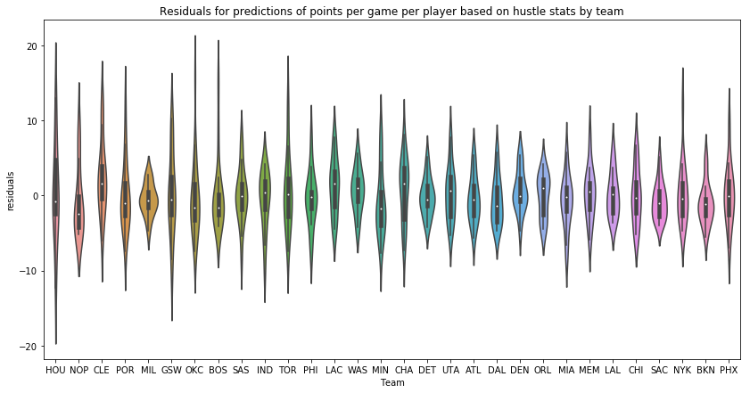

```python
baseHustleViolin = sns.violinplot(x="Team", y="residuals", data=hustleStatsWithPTS)
baseHustleViolin.set_title("Residuals for predictions of points per game per player based on hustle stats by team")
```

In the above plot we see residuals for our predictive model. Ideally we want the widest part of each violin to be close to zero. This is true for some teams (e.g. MIL, DET, DEN, SAC). However, many teams have very high residuals, and have very thin violins, showing that for many of their players the base hustle stats don't effectively predict the number of points they score in a game.

### 6.B Player Point Prediction based on Calculated Hustle Score

We then try to predict the number of points each player scores per game based on our calculated hustle score. We postulate that the results of this regression will be better because in our hustle score we standardized each parameter. This is different from 6.A becuase in 6.A we took raw hustle scores without standardization.

```python
# Fit linear rergression model with one parameter and calculate residuals
hustleReg = LinearRegression()
hustleReg.fit(hustleStatsWithPTS[['HustleScore']],hustleStatsWithPTS['PTS'])
hustleStatsWithPTS['hustleResidual'] = hustleStatsWithPTS['PTS'] - hustleReg.predict(hustleStatsWithPTS[['HustleScore']])
```

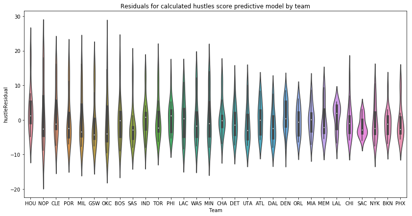

```python
hustleViolin = sns.violinplot(x="Team", y="hustleResidual", data=hustleStatsWithPTS)
hustleViolin.set_title("Residuals for calculated hustles score predictive model by team")
```

We see higher residuals in this plot than in the previous one. Only a few teams (e.g. SAC) have short violins with many points clustered around 0. Thus our calculated hustle score does not effectively predict player points.

### 6.C Predict Player Points with Regular Statistics

We try to predict points using regular statistics (e.g. assists, blocks, turnovers, deffensive rebounds, and field goal percentage) to see if it's more effective than using our hustle statistics.

```python
# Merge the team column into the regular stats table
regularStatsWithTeam = regularStats.merge(hustleStats[['Player', 'Team', 'year']], on=['Player', 'year']).drop(['#'], axis=1)
regularStatsWithTeam = regularStatsWithTeam.drop(['GP', 'MIN'], axis=1)
regularStatsWithTeam.head()
```

|  | Player | PTS | FGM | FGA | FG% | 3PM | 3PA | 3P% | FTM | FTA | ... | OREB | DREB | REB | AST | STL | BLK | TOV | EFF | year | Team |
| --- | --- | --- | --- | --- | --- | --- | --- | --- | --- | --- | --- | --- | --- | --- | --- | --- | --- | --- | --- | --- | --- |
| 0 | Russell Westbrook | 31.6 | 10.2 | 24.0 | 42.5 | 2.5 | 7.2 | 34.3 | 8.8 | 10.4 | ... | 1.7 | 9.0 | 10.7 | 10.4 | 1.6 | 0.4 | 5.4 | 33.8 | 2016-17 | OKC |
| 1 | James Harden | 29.1 | 8.3 | 18.9 | 44.0 | 3.2 | 9.3 | 34.7 | 9.2 | 10.9 | ... | 1.2 | 7.0 | 8.1 | 11.2 | 1.5 | 0.5 | 5.7 | 32.4 | 2016-17 | HOU |
| 2 | Isaiah Thomas | 28.9 | 9.0 | 19.4 | 46.3 | 3.2 | 8.5 | 37.9 | 7.8 | 8.5 | ... | 0.6 | 2.1 | 2.7 | 5.9 | 0.9 | 0.2 | 2.8 | 24.7 | 2016-17 | BOS |
| 3 | Anthony Davis | 28.0 | 10.3 | 20.3 | 50.5 | 0.5 | 1.8 | 29.9 | 6.9 | 8.6 | ... | 2.3 | 9.5 | 11.8 | 2.1 | 1.3 | 2.2 | 2.4 | 31.1 | 2016-17 | NOP |
| 4 | DeMar DeRozan | 27.3 | 9.7 | 20.9 | 46.7 | 0.4 | 1.7 | 26.6 | 7.4 | 8.7 | ... | 0.9 | 4.3 | 5.2 | 3.9 | 1.1 | 0.2 | 2.4 | 22.7 | 2016-17 | TOR |

5 rows × 21 columns

```python
# Fit linear regression model
regularStatsReg = LinearRegression()
regularStatsReg.fit(regularStatsWithTeam[['AST', 'BLK', 'TOV', 'DREB', 'FG%']], regularStatsWithTeam['PTS'])
```

```
LinearRegression(copy_X=True, fit_intercept=True, n_jobs=None,
         normalize=False)
```

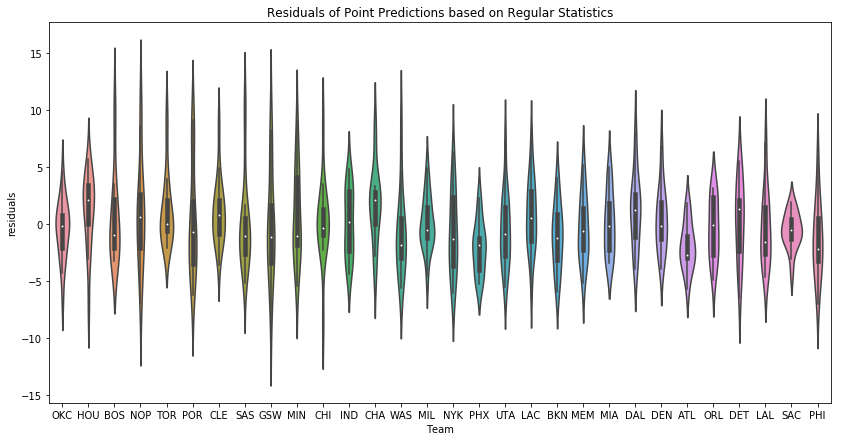

```python
# Calculate residuals and plot
regularStatsWithTeam['residuals'] = regularStatsWithTeam['PTS'] - regularStatsReg.predict(regularStatsWithTeam[['AST', 'BLK', 'TOV', 'DREB', 'FG%']])
regViolin = sns.violinplot(x="Team", y="residuals", data=regularStatsWithTeam)
regViolin.set_title("Residuals of Point Predictions based on Regular Statistics")
```

As with our earlier plots, some players' points are predicted really well by their regular stats, while others are not.

### 6.D Incorporating the HustleScore

We try to see if a combination of the hustle score with regular statistics predicts player points more effectively.

```python
# Merge calculated hustle stat into regular stats table
allStats = regularStatsWithTeam.merge(hustleStats[['Player', 'year', 'HustleScore']], on=['Player', 'year'])
allStats = allStats.dropna()
allStats.head()
```

|  | Player | PTS | FGM | FGA | FG% | 3PM | 3PA | 3P% | FTM | FTA | ... | REB | AST | STL | BLK | TOV | EFF | year | Team | residuals | HustleScore |
| --- | --- | --- | --- | --- | --- | --- | --- | --- | --- | --- | --- | --- | --- | --- | --- | --- | --- | --- | --- | --- | --- |
| 0 | Russell Westbrook | 31.6 | 10.2 | 24.0 | 42.5 | 2.5 | 7.2 | 34.3 | 8.8 | 10.4 | ... | 10.7 | 10.4 | 1.6 | 0.4 | 5.4 | 33.8 | 2016-17 | OKC | -4.292535 | 2.773719 |
| 1 | James Harden | 29.1 | 8.3 | 18.9 | 44.0 | 3.2 | 9.3 | 34.7 | 9.2 | 10.9 | ... | 8.1 | 11.2 | 1.5 | 0.5 | 5.7 | 32.4 | 2016-17 | HOU | -7.246491 | 2.866732 |
| 2 | Isaiah Thomas | 28.9 | 9.0 | 19.4 | 46.3 | 3.2 | 8.5 | 37.9 | 7.8 | 8.5 | ... | 2.7 | 5.9 | 0.9 | 0.2 | 2.8 | 24.7 | 2016-17 | BOS | 10.859517 | 1.975801 |
| 3 | Anthony Davis | 28.0 | 10.3 | 20.3 | 50.5 | 0.5 | 1.8 | 29.9 | 6.9 | 8.6 | ... | 11.8 | 2.1 | 1.3 | 2.2 | 2.4 | 31.1 | 2016-17 | NOP | 8.578676 | 3.703684 |
| 4 | DeMar DeRozan | 27.3 | 9.7 | 20.9 | 46.7 | 0.4 | 1.7 | 26.6 | 7.4 | 8.7 | ... | 5.2 | 3.9 | 1.1 | 0.2 | 2.4 | 22.7 | 2016-17 | TOR | 9.928847 | 2.061284 |

5 rows × 23 columns

```python
# Perform the same regression as earlier but with the added hustle score column
hustleRegularStatsReg = LinearRegression()
hustleRegularStatsReg.fit(allStats[['AST', 'BLK', 'TOV', 'DREB', 'FG%', 'HustleScore']], allStats['PTS'])
```

```
LinearRegression(copy_X=True, fit_intercept=True, n_jobs=None,
         normalize=False)
```

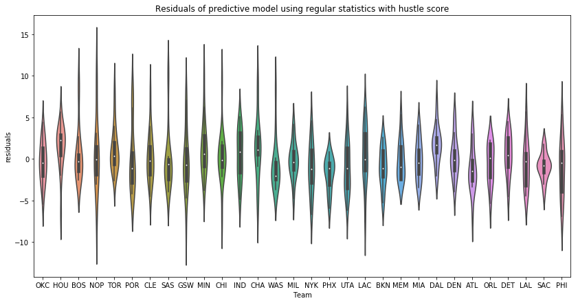

```python
allStats['residuals'] = allStats['PTS'] - hustleRegularStatsReg.predict(allStats[['AST', 'BLK', 'TOV', 'DREB', 'FG%', 'HustleScore']])
violin = sns.violinplot(x="Team", y="residuals", data=allStats)
violin.set_title("Residuals of predictive model using regular statistics with hustle score")
```

As we see here, the hustle score slightly improves the player points per game prediction, but only for certain teams.

### 6.E Predicting Team Wins based on Hustle Score

Try to see if team hustle score (sum of individual hustle scores) predicts team wins.

```python
# Sum hustle score by team and add wins to table
hustleStatsWithWins = hustleStats.groupby(['Team', 'year']).sum().merge(teamWinsTable, on=['Team', 'year'])
hustleStatsWithWins.head()
```

|  | Team | year | AGE | GP | MIN | ScreenAssists | Deflections | Loose BallsRecovered | ChargesDrawn | Contested2PT Shots | Contested3PT Shots | ContestedShots | OREB | STL | HustleScore | Wins |
| --- | --- | --- | --- | --- | --- | --- | --- | --- | --- | --- | --- | --- | --- | --- | --- | --- |
| 0 | ATL | 2016-17 | 252 | 641 | 225.3 | 11.0 | 17.3 | 6.4 | 1.09 | 39.6 | 21.6 | 61.3 | 10.6 | 8.1 | 29.289549 | 43 |
| 1 | ATL | 2017-18 | 147 | 417 | 154.9 | 6.9 | 9.5 | 6.2 | 0.46 | 25.2 | 15.3 | 40.6 | 6.0 | 5.3 | 18.294636 | 24 |
| 2 | BKN | 2016-17 | 213 | 559 | 184.1 | 7.0 | 11.0 | 5.4 | 0.37 | 40.6 | 16.6 | 57.3 | 7.2 | 5.6 | 22.446592 | 20 |
| 3 | BKN | 2017-18 | 232 | 660 | 228.5 | 8.1 | 13.0 | 7.7 | 0.52 | 44.7 | 18.3 | 63.0 | 8.9 | 6.3 | 25.372627 | 28 |
| 4 | BOS | 2016-17 | 237 | 680 | 219.6 | 9.7 | 13.8 | 6.7 | 0.73 | 38.0 | 21.0 | 59.0 | 8.1 | 6.8 | 26.164516 | 53 |

```python
# Fit linear regression model with one parameter
hustleWinsReg = LinearRegression()
hustleWinsReg.fit(hustleStatsWithWins[['HustleScore']], hustleStatsWithWins['Wins'])
```

```
LinearRegression(copy_X=True, fit_intercept=True, n_jobs=None,
         normalize=False)
```

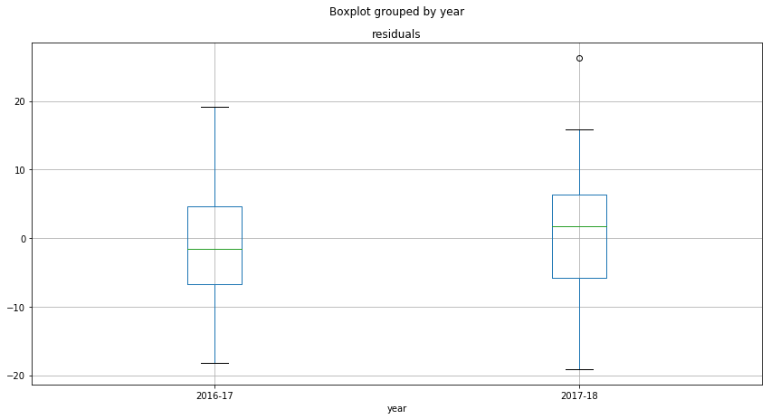

```python
# Calculate residuals and plot using boxplot
hustleStatsWithWins['residuals'] = hustleStatsWithWins['Wins'] - hustleWinsReg.predict(hustleStatsWithWins[['HustleScore']])
hustleStatsWithWins.boxplot(column=['residuals'], by='year')
```

## 7. There's no "I" in Team

The last part of the previous section showed a correlation between team hustle score and wins. We explore that further in this section and focus more on the team as opposed to individual players.

### 7.A Plotting Team HustleScore vs. Wins

```python
teamWinsTable = hustleStatsWithWins[['HustleScore', 'Wins', 'Team', 'year']]
# Merge team hustle score into table with general team stats
teamStatsTable = teamStatsTable.merge(teamWinsTable[['Team', 'year', 'Wins', 'HustleScore']], on=['Team', 'year'])
teamStatsTable.head()
```

|  | Rk | Team | G | MP | FG | FGA | FG% | 3P | 3PA | 3P% | ... | TRB | AST | STL | BLK | TOV | PF | PTS | year | Wins | HustleScore |
| --- | --- | --- | --- | --- | --- | --- | --- | --- | --- | --- | --- | --- | --- | --- | --- | --- | --- | --- | --- | --- | --- |
| 0 | 1.0 | GSW | 82 | 241.2 | 43.1 | 87.1 | 0.495 | 12.0 | 31.2 | 0.383 | ... | 44.4 | 30.4 | 9.6 | 6.8 | 14.8 | 19.3 | 115.9 | 2016-17 | 67 | 37.180985 |
| 1 | 2.0 | HOU | 82 | 241.2 | 40.3 | 87.2 | 0.462 | 14.4 | 40.3 | 0.357 | ... | 44.4 | 25.2 | 8.2 | 4.3 | 15.1 | 19.9 | 115.3 | 2016-17 | 55 | 32.453697 |
| 2 | 3.0 | DEN | 82 | 240.9 | 41.2 | 87.7 | 0.469 | 10.6 | 28.8 | 0.368 | ... | 46.4 | 25.3 | 6.9 | 3.9 | 15.0 | 19.1 | 111.7 | 2016-17 | 40 | 23.502961 |
| 3 | 4.0 | CLE | 82 | 242.4 | 39.9 | 84.9 | 0.470 | 13.0 | 33.9 | 0.384 | ... | 43.7 | 22.7 | 6.6 | 4.0 | 13.7 | 18.1 | 110.3 | 2016-17 | 51 | 22.892525 |
| 4 | 5.0 | WAS | 82 | 242.1 | 41.3 | 87.0 | 0.475 | 9.2 | 24.8 | 0.372 | ... | 42.9 | 23.9 | 8.5 | 4.1 | 14.2 | 21.3 | 109.2 | 2016-17 | 49 | 19.850076 |

5 rows × 28 columns

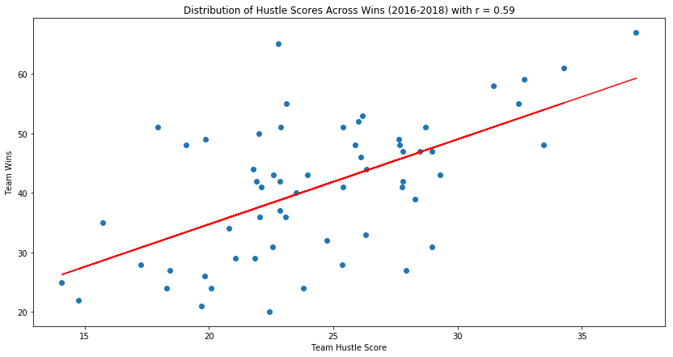

```python
# Convert type of wins column to int32 because cannot be of object type when plotting
teamStatsTable['Wins'] = teamStatsTable['Wins'].astype('int32')
x = teamStatsTable['HustleScore']
y = teamStatsTable['Wins']
fig, ax = plt.subplots()
ax.scatter(x, y)

# Calculate the slope and intercept for the best fit line
(m, b) = np.polyfit(teamStatsTable['HustleScore'], teamStatsTable['Wins'], 1)
# Calculate the actual best fit line
regression_line = [(m*x)+b for x in teamStatsTable['HustleScore']]
ax.plot(teamStatsTable['HustleScore'], regression_line, color='red')

# Calculate the correlation coefficient r
correlation = np.corrcoef(teamStatsTable['HustleScore'], teamStatsTable['Wins'])[0,1]

# Label the plot
ax.set_title("Distribution of Hustle Scores Across Wins (2016-2018) with r = " + str(round(correlation,2)))
ax.set_xlabel("Team Hustle Score")
ax.set_ylabel("Team Wins")
```

## 7.B Top Teams vs. Bottom Teams

To further corroborate our results from 7.A, we plot the difference between top and bottom teams for the hustle score and for other statistics. If we see a significant difference between the top and bottom teams for the hustle score but not for other statistics, then we have shown that our hustle score is meaningful.

```python
topTeams = teamStatsTable[teamStatsTable['Wins'] >= 48]
bottomTeams = teamStatsTable[teamStatsTable['Wins'] < 48]
figsize(14, 12)
```

```
Differences between Top and Bottom Teams where Ratio = Top Teams Score / Bottom Teams Score
```

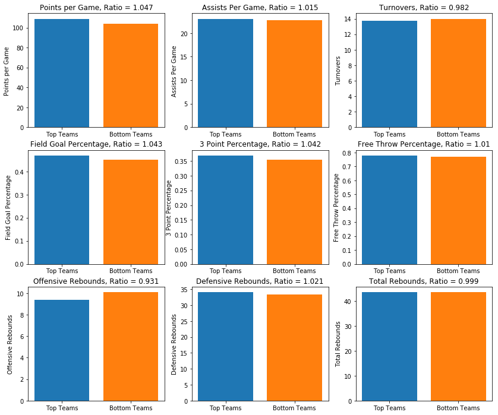

```python
def graph(ax, stat, name):
    x = topTeams[stat].median()
    y = bottomTeams[stat].median()
    ax.bar(['Top Teams'], x)
    ax.bar(['Bottom Teams'], y)
    ratio = x/y
    ax.set_title(name + ", Ratio = " + str(round(ratio, 3)))
    ax.set_ylabel(name)

print("Differences between Top and Bottom Teams where Ratio = Top Teams Score / Bottom Teams Score")
fig, axes = plt.subplots(3, 3)
graph(axes[0, 0], 'PTS', 'Points per Game')
graph(axes[0, 1], 'AST', 'Assists Per Game')
graph(axes[0, 2], 'TOV', 'Turnovers')
graph(axes[1, 0], 'FG%', 'Field Goal Percentage')
graph(axes[1, 1], '3P%', '3 Point Percentage')
graph(axes[1, 2], 'FT%', 'Free Throw Percentage')
graph(axes[2, 0], 'ORB', 'Offensive Rebounds')
graph(axes[2, 1], 'DRB', 'Defensive Rebounds')
graph(axes[2, 2], 'TRB', 'Total Rebounds')
```

```python
figsize(14, 6)
```

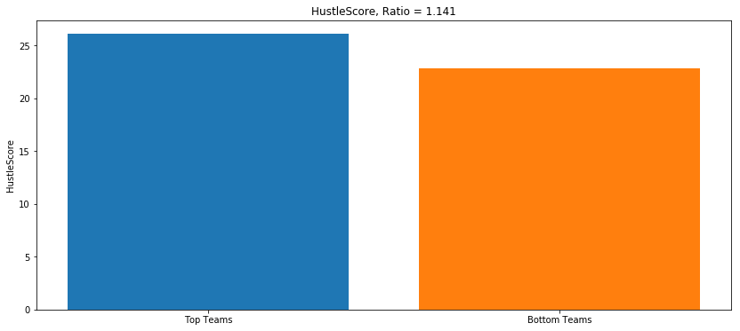

```python
fig, ax = plt.subplots()
graph(ax, 'HustleScore', 'HustleScore')
```

As seen above, the ratio of the hustle score between the top and bottom teams is almost 10% better than any of the other statistics we plotted. This shows that our hustle score is significant.

## 8. Conclusion

In our project, we tried to create a meaningful statistic to gauge player performance. To do this, we used advanced statistics from the NBA to create what we called a **HustleScore** for each player. We had trouble finding correlation between a player's HustleScore and anything else regarding individual players. However, we noticed that a team's HustleScore had a significant positive correlation with a team's overall wins.

In terms of future work, there are other advanced statistics that could be incorporated into calculating the HustleScore for each player. Some of these [statistics](https://stats.nba.com/players/speed-distance/?sort=DIST_MILES_DEF&dir=1&Season=2017-18&SeasonType=Regular%20Season) include average MPH, distance traveled, boxouts, etc. These statistics might improve our correlations and predictive models.

Based on these findings, we would recommend that NBA general managers look more into a team's hustle when trying to create a championship team. Our statistics show that a team that hustles more wins more. Due to the fact that wins is the most important team statistic, we conclude that our HustleScore is a meaningful statistic. Moneyball 2.0?!

CSV files that we downloaded (i.e. did not scrape) can be found [here](https://github.com/yklausner/yklausner.github.io).